# What NBA Data Really Tells Us, An Analysis of Efficiency and Home-Court Advantage

What does NBA data really tell us? The game of basketball has changed in many ways throughout the years. From the style of play to the athletes themselves, the NBA has evolved into a fast-paced, high-scoring league that emphasizes athleticism and skill. But what does the data tell us about these changes? Is it effective to rely purely on scoring, or does defense really win championships? How has the trend of shooting three pointers changed? Has Stephen Curry really ruined basketball? In this blog post, we will explore some key statistics and trends in the NBA to uncover what the data really tells us about the game.

## Motivating Question

What do we want to learn from this data? From this analysis, I am looking to answer three main questions, how does points per game impact your winning percentage, how has the points and 3’s attempted a game changed, and if you are leading at the half does that mean you are winning the games. This will break my blog into a few different sections, one for collection of the data and one for each question.

## Data Collection

To gather my dataset, I used the official NBA Stats API, which provides public access to stats.nba.com. This approach is both ethical and efficient compared to scraping raw web pages.

The Python package nba_api makes this easy to use. After installing it with:

```
pip install nba_api
```

I imported the endpoint LeagueStandings to pull team statistics from each regular season between 2010 and 2025. To respect API rate limits, I included a one second pause (time.sleep(1)) between requests.

After downloading, I merged this data with a second file of 3-point attempt totals to add shooting information, calculated per-game stats, and cleaned up home/road win columns. The final dataset, nba_clean_for_eda.csv, is ready for exploratory analysis.

## Finding 1 — Does Scoring More Really Lead to Winning More?

My first question was whether a team’s offensive output—specifically points per game—predicts its winning percentage.

Using my cleaned dataset, I calculated the correlation between PointsPG and WinPCT and created a scatterplot with a regression line:

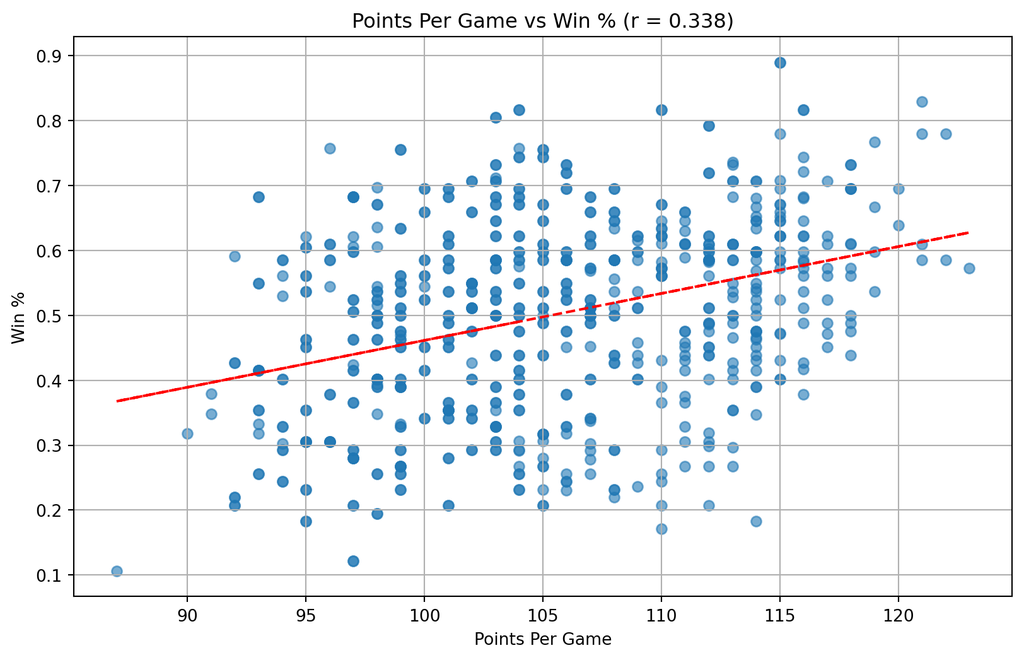

The correlation was only .338, which is really low. To dig deeper, I replaced raw points with point differential per game (average points minus points allowed). This time, the correlation jumped to an almost perfect linear relationship.

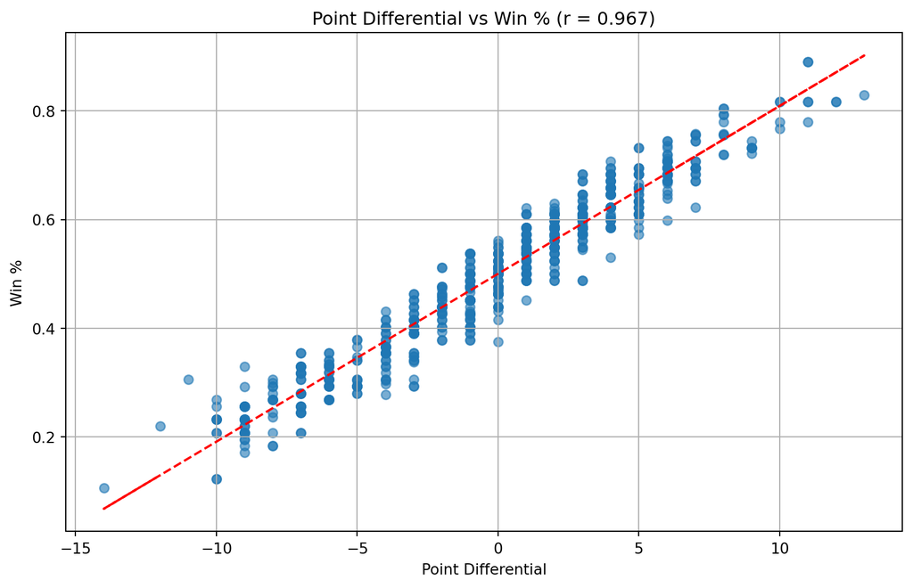

In other words, it’s not just about scoring a lot—the key is consistently outscoring your opponents. Teams that win big tend to defend well, not just score more.

## Finding 2 — How Have Scoring and 3-Point Attempts Changed Over Time?

Next, I wanted to see how the NBA’s style of play has changed over the last 15 seasons. Specifically, how average points per game and 3-point attempts per game have evolved.

To explore this, I grouped the data by season and calculated the league averages for both stats:

| SEASON_YEAR_FULL | Avg_PointsPG | Avg_FG3A_PG |
| --- | --- | --- |
| 2010-11 | 99.500000 | 15.597818 |
| 2011-12 | 96.333333 | 18.381313 |
| 2012-13 | 98.133333 | 17.583801 |
| 2013-14 | 101.033333 | 20.078819 |
| 2014-15 | 100.000000 | 21.192953 |
| 2015-16 | 102.711864 | 21.929229 |
| 2016-17 | 105.677966 | 24.597378 |
| 2017-18 | 106.333333 | 26.601021 |
| 2018-19 | 111.200000 | 28.716588 |
| 2019-20 | 111.666667 | 33.655473 |
| 2020-21 | 112.133333 | 34.639815 |
| 2021-22 | 110.600000 | 34.845723 |
| 2022-23 | 114.600000 | 33.845466 |
| 2023-24 | 114.233333 | 34.849957 |
| 2024-25 | 113.900000 | 37.126053 |

Then, I plotted both metrics on the same chart — points per game in blue and 3-point attempts per game in red:

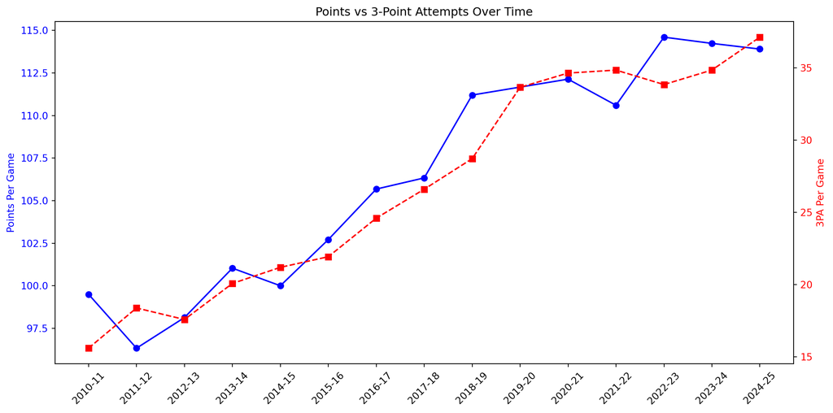

The results are striking: since the 2010–11 season, the average team has increased its scoring by nearly 15 points per game, and the number of 3-pointers attempted has more than doubled.

This confirms what fans already sense: the NBA has become a three-point-dominated league. The rise of players like Stephen Curry and the league’s emphasis on spacing and efficiency have completely reshaped how teams approach offense.

## Finding 3 — Does Home-Court Advantage Still Matter?

Finally, I wanted to test whether the long-held belief in home-court advantage still holds true in modern basketball.

Using the cleaned dataset, I separated each team’s home and road records to compare league-wide averages:

Then I created a simple bar comparison:

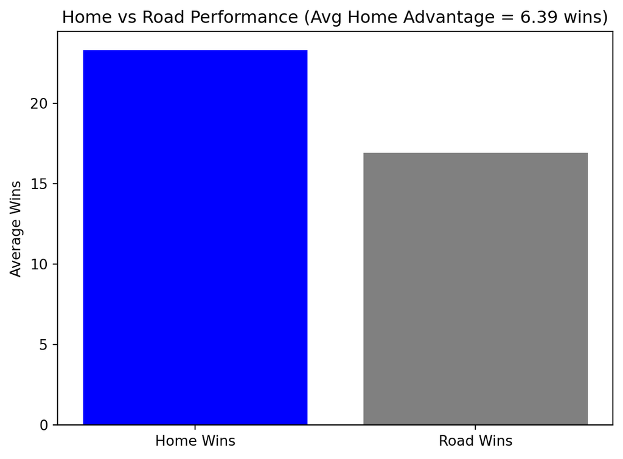

Across all seasons from 2010 to 2025, teams win about six more games per year at home than on the road. Even in an era of private jets, advanced analytics, and neutralized travel schedules, the home crowd and familiarity still provide a measurable edge.

## Conclusion

Through this analysis, we can see that NBA data tells a much richer story than the box score alone. Scoring a lot helps, but it’s not the main driver of success — what really matters is scoring efficiently and defending well enough to create a strong point differential.

Lastly, even with all the changes in pace, analytics, and travel, home-court advantage still exists. Teams continue to win noticeably more often in their home arenas.

Altogether, the data reveals a league that’s faster, more three-point heavy, and still deeply human. While numbers and trends shape how the game evolves, the fundamentals — teamwork, defense, and energy — continue to define what it takes to win.

## My Repository

Here is a link to my other repository that has all of my data collection and EDA:

[Github](https://github.com/emclayburn/Stat386-data-acquisition)